# signeR

### 7.6: Cox regression

signeR can also evaluate the combined effect on survival of exposure levels to different signatures. The following command fits Cox's proportional hazards model on exposures. It generates a p-values boxplot and a forestplot (form package **forestplot**) to show the relevance of each mutational signature to survival.

```r
BRCA_labels <- c("wt","BRCA+","BRCA+","BRCA+","BRCA+","BRCA+","BRCA+",
    "wt","wt","wt","wt","BRCA+","wt","BRCA+","BRCA+","wt","wt","wt",
    "wt","wt","wt")

ExpSurvMd <- ExposureSurvModel(Exposures=signatures$SignExposures, surv=su, addata=data.frame(as.factor(BRCA_labels)))
```

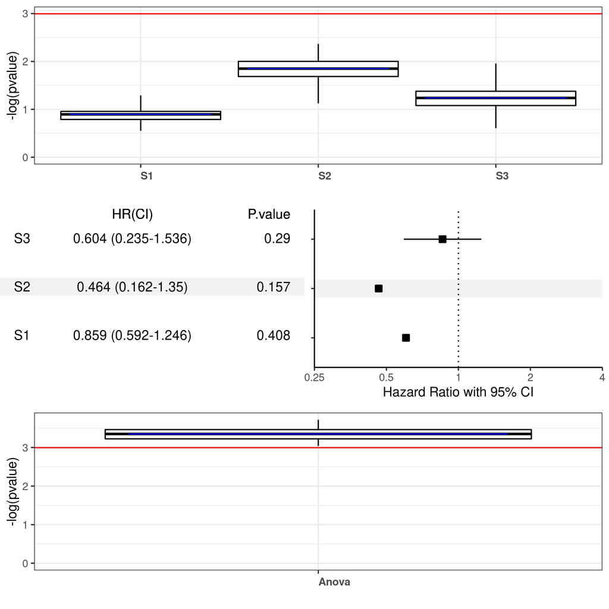

Forestplot: Cox proportional model p-values and hazard ratios for each signature.

## 8: Unsupervised approaches to exposure analysis

When no addtional information is available for the samples analysed, **signeR** can search patterns on estimated exposures. Unsupervised analysis can be performed on all generated samples of the exposure matrix and consistent results are reported as significant.

### 8.1: Hierarquical Clustering

Samples can be hierarquicaly clustered according to their exposures to mutational signatures. The function `HClustExp` applies R function `hclust` to each sampled exposure matrix. Dendogram branches consistently found on most of the analyses are reported:

```r
# feature values, respective to each row of the mutation count matrix
HCE <- HClustExp(signatures$SignExposures,method.dist="euclidean", method.hclust="average")
```

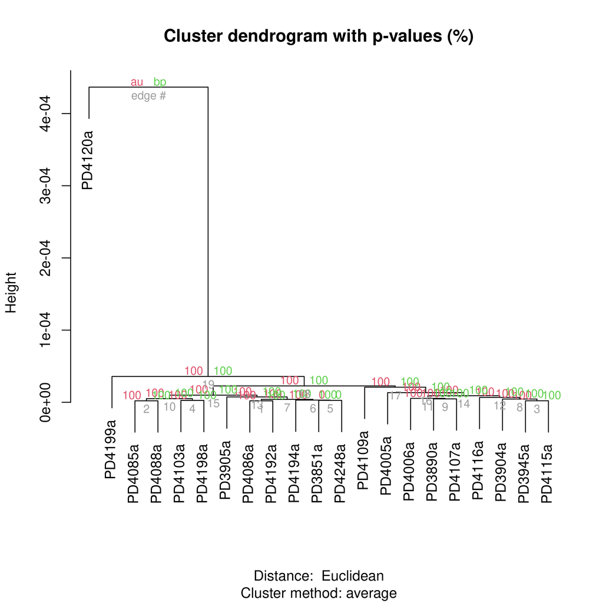

Hierarquical structure found on data, each branch showing the frequency of its occurance in the analysis of sampled exposure matrices.

### 8.2: Fuzzy Clustering

**signeR** can also perform a Fuzzy clustering of the samples according to their exposures to mutational signatures. The function `FuzzyClustExp` applies a clustering algorithm (hard or fuzzy) on each sampled exposure matrix and averages the fuzzy memberships degrees of samples to clusters. The number of cluster can be defined by the user (Clim parameter), otherwise different numbers of clusters are tested and the one that maximizes the PBMF index is used (the search algorithm used is similar to the one applied to estimate the number of signatures present in a dataset):

```r
FCE <- FuzzyClustExp(signatures$SignExposures, Clim=c(3,7))
```

```
## Evaluating models with the number of groups ranging from 3 to 7, please be patient.
## Testing 3 groups.
## Testing 4 groups.
## Testing 5 groups.
## Testing 6 groups.
## Testing 7 groups.
## Optimum number of groups is 6. Performing final clustering.
```

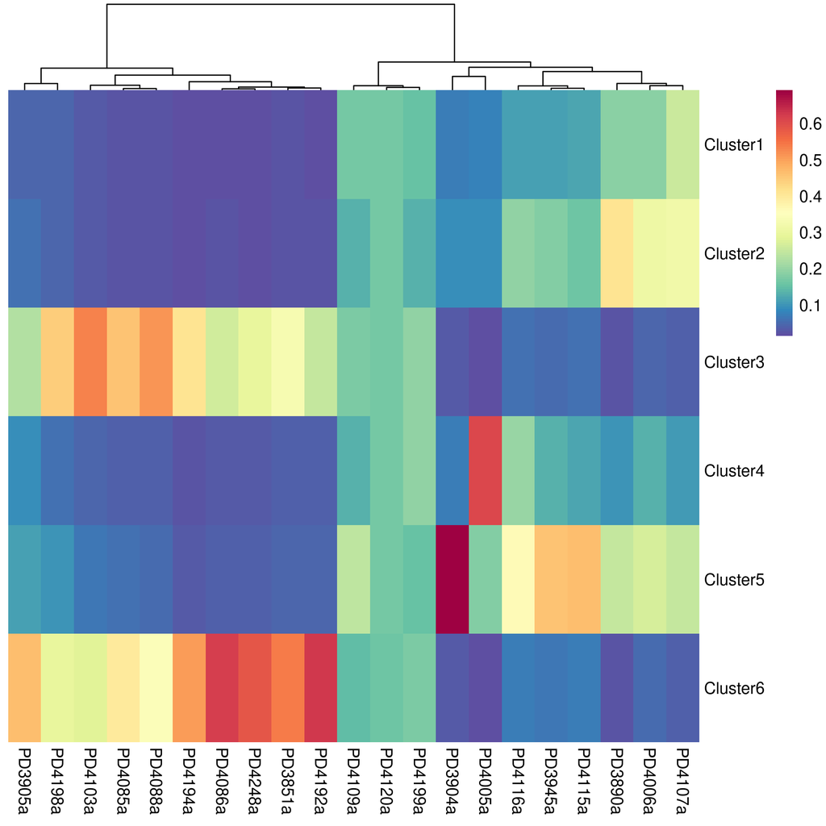

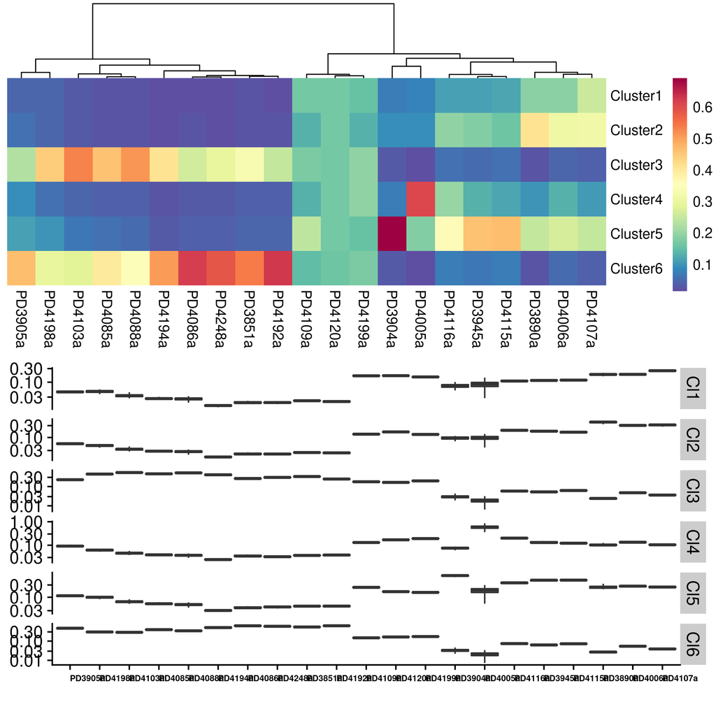

Heatmap showing the mean fuzzy memberships degrees of samples to clusters.

The function's output is a list of three elements: the mean matrix of fuzzy memberships degrees of samples to clusters, the full array of all fuzzy memberships degrees found by the analysis of sampled exposure matrices and the matrix of memberships degrees found by the analysis of median exposures of samples to signatures.

## 9: Frequently Asked Questions

### 9.1: Citing signeR

If you use the **signeR** package in your work, please cite it:

```r
citation("signeR")
```

```
##
##
##   Rafael A. Rosales, Rodrigo D. Drummond, Renan Valieris, Emmanuel
##   Dias-Neto, and Israel T. da Silva (2016): signeR: An empirical
##   Bayesian approach to mutational signature discovery. Bioinformatics
##   September 1, 2016 doi:10.1093/bioinformatics/btw572
##
## A BibTeX entry for LaTeX users is
##
##   @Article{,
##     title = {signeR: An empirical Bayesian approach to mutational signature discovery.},
##     author = {Rafael A. Rosales and Rodrigo D. Drummond and Renan Valieris and Emmanuel Dias-Neto and Israel T. da Silva},
##     year = {2016},
##     journal = {Bioinformatics},
##     doi = {10.1093/bioinformatics/btw572},
##   }
```

### 9.2: Compilation errors on OS X

OS X users might get compilation errors similar to these:

```
ld: warning: directory not found for option '-L/usr/local/lib/x86_64'
ld: library not found for -lgfortran
ld: library not found for -lquadmath
```

This problem arises when the machine is missing gfortran libraries necessary to compile RcppArmadillo and signeR. To install the missing libraries, execute these lines on a terminal:

```
curl -O http://r.research.att.com/libs/gfortran-4.8.2-darwin13.tar.bz2
sudo tar fvxz gfortran-4.8.2-darwin13.tar.bz2 -C /
```

For more information [see this post](http://thecoatlessprofessor.com/programming/rcpp-rcpparmadillo-and-os-x-mavericks-lgfortran-and-lquadmath-error/) and the [Rcpp FAQ, section 2.16](http://dirk.eddelbuettel.com/code/rcpp/Rcpp-FAQ.pdf).

### 9.3: Missing library headers

Some packages that signeR depends on requires that 3rd party library headers be installed. If you see errors like:

```
Error: checking for curl-config... no
         Cannot find curl-config
```

It means you need to install these headers with your package manager. For example on ubuntu:

```
$ sudo apt-get install libcurl4-openssl-dev
```

## 10: References

L. B. Alexandrov, S. Nik-Zainal, D. C. Wedge, P. J. Campbell, and M. R. Stratton. Deciphering Signatures of Mutational Processes Operative in Human Cancer. Cell Reports, 3(1):246-259, Jan. 2013. [ [DOI](http://dx.doi.org/10.1016/j.celrep.2012.12.008) ]

A. Fischer, C. J. Illingworth, P. J. Campbell, and V. Mustonen. EMu: probabilistic inference of mutational processes and their localization in the cancer genome. Genome biology, 14(4):R39, Apr. 2013. [ [DOI](http://dx.doi.org/10.1186/gb-2013-14-4-r39) ]

## Debug Info

```r
print(names(dev.cur()))
```

```
## [1] "png"
```